# MSBA 6420 Homework 4

### Nisanth Dheram

#### I used Python to run 4 different models for this assignment – Decision Tree, k-NN, Logistic Regression and Naive Bayes and compare their performance for both the parts.

### Part 1: Accuracy

#### Firstly, the data is examined to understand the different variables. The first 54 variables are related to word or character frequency and the next 3 variables are related to capital letters. The final variable is the label for ‘spam’ or ‘non-spam’ mails.

```python
from pandas import Series, DataFrame

import pandas as pd

from sklearn import tree
from sklearn import metrics, cross_validation
from sklearn.cross_validation import cross_val_score, train_test_split
import matplotlib.pyplot as plt
import numpy as np
from IPython.display import display, HTML

feature_names = ['word_freq_make',
'word_freq_address',
'word_freq_all',
'word_freq_3d',
'word_freq_our',
'word_freq_over',
'word_freq_remove',
'word_freq_internet',
'word_freq_order',
'word_freq_mail',
'word_freq_receive',
'word_freq_will',
'word_freq_people',
'word_freq_report',
'word_freq_addresses',
'word_freq_free',
'word_freq_business',
'word_freq_email',
'word_freq_you',
'word_freq_credit',
'word_freq_your',
'word_freq_font',
'word_freq_000',
'word_freq_money',
'word_freq_hp',
'word_freq_hpl',
'word_freq_george',
'word_freq_650',
'word_freq_lab',
'word_freq_labs',
'word_freq_telnet',
'word_freq_857',
'word_freq_data',
'word_freq_415',
'word_freq_85',
'word_freq_technology',
'word_freq_1999',
'word_freq_parts',
'word_freq_pm',
'word_freq_direct',
'word_freq_cs',
'word_freq_meeting',
'word_freq_original',
'word_freq_project',
'word_freq_re',
'word_freq_edu',
'word_freq_table',
'word_freq_conference',
'char_freq_;',
'char_freq_(',
'char_freq_[',
'char_freq_!',
'char_freq_$',
'char_freq_#',
'capital_run_length_average',
'capital_run_length_longest',
'capital_run_length_total','spam_flag']

class_names = ['non-spam','spam']

data=pd.read_csv('spambase.data.txt',header=None,names=feature_names)

data.head(2)
```

|  | word_freq_make | word_freq_address | word_freq_all | word_freq_3d | word_freq_our | word_freq_over | word_freq_remove | word_freq_internet | word_freq_order | word_freq_mail | ... | char_freq_; | char_freq_( | char_freq_[ | char_freq_! | char_freq_$ | char_freq_# | capital_run_length_average | capital_run_length_longest | capital_run_length_total | spam_flag |
| --- | --- | --- | --- | --- | --- | --- | --- | --- | --- | --- | --- | --- | --- | --- | --- | --- | --- | --- | --- | --- | --- |
| 0 | 0.00 | 0.64 | 0.64 | 0.0 | 0.32 | 0.00 | 0.00 | 0.00 | 0.0 | 0.00 | ... | 0.0 | 0.000 | 0.0 | 0.778 | 0.00 | 0.000 | 3.756 | 61 | 278 | 1 |
| 1 | 0.21 | 0.28 | 0.50 | 0.0 | 0.14 | 0.28 | 0.21 | 0.07 | 0.0 | 0.94 | ... | 0.0 | 0.132 | 0.0 | 0.372 | 0.18 | 0.048 | 5.114 | 101 | 1028 | 1 |

2 rows × 58 columns

#### Next, checks were performed to understand if the data has any missing or incorrect values by looking at the distributions of the variables. The data seems to have no issues so we can proceed forward.

```python
data.describe()
```

|  | word_freq_make | word_freq_address | word_freq_all | word_freq_3d | word_freq_our | word_freq_over | word_freq_remove | word_freq_internet | word_freq_order | word_freq_mail | ... | char_freq_; | char_freq_( | char_freq_[ | char_freq_! | char_freq_$ | char_freq_# | capital_run_length_average | capital_run_length_longest | capital_run_length_total | spam_flag |
| --- | --- | --- | --- | --- | --- | --- | --- | --- | --- | --- | --- | --- | --- | --- | --- | --- | --- | --- | --- | --- | --- |
| count | 4601.000000 | 4601.000000 | 4601.000000 | 4601.000000 | 4601.000000 | 4601.000000 | 4601.000000 | 4601.000000 | 4601.000000 | 4601.000000 | ... | 4601.000000 | 4601.000000 | 4601.000000 | 4601.000000 | 4601.000000 | 4601.000000 | 4601.000000 | 4601.000000 | 4601.000000 | 4601.000000 |
| mean | 0.104553 | 0.213015 | 0.280656 | 0.065425 | 0.312223 | 0.095901 | 0.114208 | 0.105295 | 0.090067 | 0.239413 | ... | 0.038575 | 0.139030 | 0.016976 | 0.269071 | 0.075811 | 0.044238 | 5.191515 | 52.172789 | 283.289285 | 0.394045 |
| std | 0.305358 | 1.290575 | 0.504143 | 1.395151 | 0.672513 | 0.273824 | 0.391441 | 0.401071 | 0.278616 | 0.644755 | ... | 0.243471 | 0.270355 | 0.109394 | 0.815672 | 0.245882 | 0.429342 | 31.729449 | 194.891310 | 606.347851 | 0.488698 |
| min | 0.000000 | 0.000000 | 0.000000 | 0.000000 | 0.000000 | 0.000000 | 0.000000 | 0.000000 | 0.000000 | 0.000000 | ... | 0.000000 | 0.000000 | 0.000000 | 0.000000 | 0.000000 | 0.000000 | 1.000000 | 1.000000 | 1.000000 | 0.000000 |
| 25% | 0.000000 | 0.000000 | 0.000000 | 0.000000 | 0.000000 | 0.000000 | 0.000000 | 0.000000 | 0.000000 | 0.000000 | ... | 0.000000 | 0.000000 | 0.000000 | 0.000000 | 0.000000 | 0.000000 | 1.588000 | 6.000000 | 35.000000 | 0.000000 |
| 50% | 0.000000 | 0.000000 | 0.000000 | 0.000000 | 0.000000 | 0.000000 | 0.000000 | 0.000000 | 0.000000 | 0.000000 | ... | 0.000000 | 0.065000 | 0.000000 | 0.000000 | 0.000000 | 0.000000 | 2.276000 | 15.000000 | 95.000000 | 0.000000 |
| 75% | 0.000000 | 0.000000 | 0.420000 | 0.000000 | 0.380000 | 0.000000 | 0.000000 | 0.000000 | 0.000000 | 0.160000 | ... | 0.000000 | 0.188000 | 0.000000 | 0.315000 | 0.052000 | 0.000000 | 3.706000 | 43.000000 | 266.000000 | 1.000000 |
| max | 4.540000 | 14.280000 | 5.100000 | 42.810000 | 10.000000 | 5.880000 | 7.270000 | 11.110000 | 5.260000 | 18.180000 | ... | 4.385000 | 9.752000 | 4.081000 | 32.478000 | 6.003000 | 19.829000 | 1102.500000 | 9989.000000 | 15841.000000 | 1.000000 |

8 rows × 58 columns

```python
import math as mt

def tfidf(column):
    nt = len([i for i in column if i > 0])
    if(nt==0):
        return column*0
    else:
        doc_nt = 1+mt.log10(float(len(column))/float(nt))
        return column*doc_nt

word_freq_tfidf = data.iloc[:,0:54].apply(tfidf,axis = 1)
#word_freq_tfidf.head(2)
```

```python
data_tfidf = pd.concat([word_freq_tfidf,data.iloc[:,54:]],axis=1)
data_tfidf.head(2)
```

|  | word_freq_make | word_freq_address | word_freq_all | word_freq_3d | word_freq_our | word_freq_over | word_freq_remove | word_freq_internet | word_freq_order | word_freq_mail | ... | char_freq_; | char_freq_( | char_freq_[ | char_freq_! | char_freq_$ | char_freq_# | capital_run_length_average | capital_run_length_longest | capital_run_length_total | spam_flag |
| --- | --- | --- | --- | --- | --- | --- | --- | --- | --- | --- | --- | --- | --- | --- | --- | --- | --- | --- | --- | --- | --- |
| 0 | 0.000000 | 1.138017 | 1.138017 | 0.0 | 0.569008 | 0.000000 | 0.000000 | 0.000000 | 0.0 | 0.000000 | ... | 0.0 | 0.000000 | 0.0 | 1.383402 | 0.000000 | 0.000000 | 3.756 | 61 | 278 | 1 |
| 1 | 0.280235 | 0.373647 | 0.667227 | 0.0 | 0.186824 | 0.373647 | 0.280235 | 0.093412 | 0.0 | 1.254387 | ... | 0.0 | 0.176148 | 0.0 | 0.496417 | 0.240202 | 0.064054 | 5.114 | 101 | 1028 | 1 |

2 rows × 58 columns

#### We then define the features and target dataframes and observe the breakdown of classes of our target variable

### Model Pre-processing

```python
#Hack to use original data without TFIDF
#data_tfidf = data

#Using TFIDF data
features = data_tfidf.iloc[:,0:57]
target = data_tfidf.iloc[:,57:]
target.columns = ['Actual']

n_samples, n_features = data_tfidf.shape

print ('The dimensions of the data set are', n_samples, 'by', n_features)
print ('The classes are : {} for spam and {} for non-spam \n'\
       .format(data_tfidf['spam_flag'].unique()[0],data_tfidf['spam_flag'].unique()[1]))

# Displaying the breakdown of the data into respective classes.
classes = (data_tfidf['spam_flag'].value_counts()/len(data_tfidf['spam_flag']))*100
print ('The breakdown of the class are below :')
print (classes)
```

```
('The dimensions of the data set are', 4601, 'by', 58)
The classes are : 1 for spam and 0 for non-spam

The breakdown of the class are below :
0    60.595523
1    39.404477
Name: spam_flag, dtype: float64
```

#### Model evaluation metrics have been defined using user-defined functions so that we can call them for each model

### Evaluation metrics

```python
from sklearn.metrics import confusion_matrix
import matplotlib.pyplot as plt
import itertools

# This function prints and plots the confusion matrix.Normalization can be applied by setting `normalize=True`.

def plot_confusion_matrix(cm, classes,
                          normalize=False,
                          title='Confusion matrix',
                          cmap=plt.cm.Blues):
    plt.imshow(cm, interpolation='nearest', cmap=cmap)
    plt.title(title)
    plt.colorbar()
    tick_marks = np.arange(len(classes))
    plt.xticks(tick_marks, classes, rotation=45)
    plt.yticks(tick_marks, classes)

    if normalize:
        cm = cm.astype('float') / cm.sum(axis=1)[:, np.newaxis]
        print("Normalized confusion matrix")
    else:
        print('Confusion matrix, without normalization')

    thresh = cm.max() / 2.
    for i, j in itertools.product(range(cm.shape[0]), range(cm.shape[1])):
        plt.text(j, i, cm[i, j],
                 horizontalalignment="center",
                 color="white" if cm[i, j] > thresh else "black")

    plt.tight_layout()
    plt.ylabel('Predicted label')
    plt.xlabel('True label')

def model_evaluation(model,features,target,class_names,cnf_normalize=False):

    # importing necessary libraries
    from sklearn.metrics import f1_score,matthews_corrcoef,cohen_kappa_score,roc_curve,roc_auc_score,auc

    predicted = cross_validation.cross_val_predict(model, features, target['Actual'], cv=10)

    scores = cross_val_score(model, features, target['Actual'], cv=10)

    #Accuracy
    # The mean score and the 95% confidence interval of the score estimate are hence given by:
    display(HTML('<br><b>Accuracy:</b>'))
    print("Accuracy: %0.2f (+/- %0.2f)" % (scores.mean(), scores.std() * 2))

    # Confusion matrix
    conf_mtrx_dt = confusion_matrix(target['Actual'], predicted)

    plt.figure()
    plot_confusion_matrix(conf_mtrx_dt, classes=class_names,normalize=cnf_normalize,\
                          title='Confusion matrix')
    plt.show()
    display(HTML('<br><b>Confusion Matrix</b>'))
    display(pd.crosstab(predicted,target['Actual']))

    #Classification report
    display(HTML('<br><b>Classification Report</b>'))
    print metrics.classification_report(target['Actual'], predicted)

    # F measure
    display(HTML('<br><b>F Measure</b>'))
    print(f1_score(target['Actual'], predicted, average='binary'))

    # kappa statistic
    display(HTML('<br><b>Kappa Score</b>'))
    print(cohen_kappa_score(target['Actual'], predicted))

    # Matthews Correlation Coefficient
    display(HTML('<br><b> Matthews correlation coefficient</b>'))
    print(matthews_corrcoef(target['Actual'], predicted))
```

## Decision Tree

#### After trying out different parameters, we observe that a max_depth = 20 nd min_samples_leaf = 10 and using TFIDF lead to the highest accuracy

```python
#Without using TFIDF data
features = data.iloc[:,0:57]
target = data.iloc[:,57:]
target.columns = ['Actual']

# We start with initializing our classifier
clf = tree.DecisionTreeClassifier(criterion='entropy',max_depth = 20,min_samples_leaf =10, random_state =1000)

scores = cross_val_score(clf, features, target['Actual'], cv=10)

#Accuracy
# The mean score and the 95% confidence interval of the score estimate are hence given by:
display(HTML('<br><b>Accuracy:</b>'))
print("Accuracy: %0.2f (+/- %0.2f)" % (scores.mean(), scores.std() * 2))
```

**Accuracy:**

```
Accuracy: 0.90 (+/- 0.07)
```

```python
#Using TFIDF data
features = data_tfidf.iloc[:,0:57]
target = data_tfidf.iloc[:,57:]
target.columns = ['Actual']

# We start with initializing our classifier
clf = tree.DecisionTreeClassifier(criterion='entropy',max_depth = 20,min_samples_leaf =10, random_state =1000)

scores = cross_val_score(clf, features, target['Actual'], cv=10)

#Accuracy
# The mean score and the 95% confidence interval of the score estimate are hence given by:
display(HTML('<br><b>Accuracy:</b>'))
print("Accuracy: %0.2f (+/- %0.2f)" % (scores.mean(), scores.std() * 2))
```

**Accuracy:**

```
Accuracy: 0.91 (+/- 0.06)
```

**Accuracy:**

```
Accuracy: 0.91 (+/- 0.06)
Confusion matrix, without normalization
```

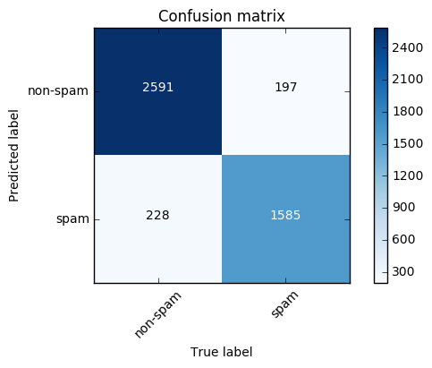

**Confusion Matrix**

| Actual row_0 | 0 | 1 |
| --- | --- | --- |
| 0 | 2591 | 228 |
| 1 | 197 | 1585 |

**Classification Report**

```
             precision    recall  f1-score   support

          0       0.92      0.93      0.92      2788
          1       0.89      0.87      0.88      1813

avg / total       0.91      0.91      0.91      4601
```

**F Measure**

```
0.881780250348
```

**Kappa Score**

```
0.805991390271
```

**Matthews correlation coefficient**

```
0.806072105071
```

```python
# Model Evaluation using cross validation
model_evaluation(clf,features,target,class_names,cnf_normalize=False)
```

```python
## Tree Visualization
from IPython.display import Image
from sklearn.externals.six import StringIO
import pydot

clf = clf.fit(features,target)

dot_data = StringIO()
tree.export_graphviz(clf, out_file=dot_data,
                         feature_names=feature_names,
                         class_names=class_names,
                         filled=True, rounded=True,
                         special_characters=True)
(graph,) = pydot.graph_from_dot_data(dot_data.getvalue())

#from IPython.display import Image #needed to render in notebook
#Image(graph.create_png())

import os
import graphviz

tree.export_graphviz(clf, out_file=os.getcwd() + os.pathsep + "spam.dot")
with open(os.getcwd() + os.pathsep + "spam.dot") as f:
    dot_graph = f.read()
graphviz.Source(tree.export_graphviz(clf))

# we can store the plot locally as odf
graph.write_pdf(os.getcwd() + os.pathsep + "spam.pdf")
# for png format:
pydot.graph_from_dot_data(dot_data.getvalue())[0].write_png(os.getcwd() + os.pathsep + "spam.png")

# we can also load these files on our notebook
from IPython.display import Image #needed to render in notebook
Image(os.getcwd() + os.pathsep + "spam.png")
```

[figure not shown]

## K-NN

```python
from sklearn.preprocessing import MinMaxScaler

min_max=MinMaxScaler()
features_normal = DataFrame(min_max.fit_transform(data_tfidf.iloc[:,0:57]),columns = feature_names[0:57])

data_tfidf_normal = pd.concat([features_normal,data_tfidf.iloc[:,57:]],axis=1)
data_tfidf_normal.head(5)

min_max=MinMaxScaler()
features_normal = DataFrame(min_max.fit_transform(data.iloc[:,0:57]),columns = feature_names[0:57])
data_normal = pd.concat([features_normal,data.iloc[:,57:]],axis=1)
data_normal.head(5)
```

|  | word_freq_make | word_freq_address | word_freq_all | word_freq_3d | word_freq_our | word_freq_over | word_freq_remove | word_freq_internet | word_freq_order | word_freq_mail | ... | char_freq_; | char_freq_( | char_freq_[ | char_freq_! | char_freq_$ | char_freq_# | capital_run_length_average | capital_run_length_longest | capital_run_length_total | spam_flag |
| --- | --- | --- | --- | --- | --- | --- | --- | --- | --- | --- | --- | --- | --- | --- | --- | --- | --- | --- | --- | --- | --- |
| 0 | 0.000000 | 0.044818 | 0.125490 | 0.0 | 0.032 | 0.000000 | 0.000000 | 0.000000 | 0.000000 | 0.000000 | ... | 0.000000 | 0.000000 | 0.0 | 0.023955 | 0.000000 | 0.000000 | 0.002502 | 0.006007 | 0.017487 | 1 |
| 1 | 0.046256 | 0.019608 | 0.098039 | 0.0 | 0.014 | 0.047619 | 0.028886 | 0.006301 | 0.000000 | 0.051705 | ... | 0.000000 | 0.013536 | 0.0 | 0.011454 | 0.029985 | 0.002421 | 0.003735 | 0.010012 | 0.064836 | 1 |
| 2 | 0.013216 | 0.000000 | 0.139216 | 0.0 | 0.123 | 0.032313 | 0.026135 | 0.010801 | 0.121673 | 0.013751 | ... | 0.002281 | 0.014664 | 0.0 | 0.008498 | 0.030651 | 0.000504 | 0.008008 | 0.048458 | 0.142551 | 1 |
| 3 | 0.000000 | 0.000000 | 0.000000 | 0.0 | 0.063 | 0.000000 | 0.042641 | 0.056706 | 0.058935 | 0.034653 | ... | 0.000000 | 0.014048 | 0.0 | 0.004218 | 0.000000 | 0.000000 | 0.002303 | 0.003905 | 0.011995 | 1 |
| 4 | 0.000000 | 0.000000 | 0.000000 | 0.0 | 0.063 | 0.000000 | 0.042641 | 0.056706 | 0.058935 | 0.034653 | ... | 0.000000 | 0.013843 | 0.0 | 0.004157 | 0.000000 | 0.000000 | 0.002303 | 0.003905 | 0.011995 | 1 |

5 rows × 58 columns

```python
#Not using TFIDF data
features = data_normal.iloc[:,0:57]
target = data_normal.iloc[:,57:]
target.columns = ['Actual']
```

```python
# import necessary libraries and specify that graphs should be plotted inline.
%matplotlib inline
import numpy as np
import matplotlib.pyplot as plt
from matplotlib.colors import ListedColormap
from sklearn import neighbors, datasets

for n_neighbors in range(3,16,2):
    # we create an instance of Neighbours Classifier and fit the data.
    clf = neighbors.KNeighborsClassifier(n_neighbors, weights = 'distance')

    predicted = cross_validation.cross_val_predict(clf, features, target['Actual'], cv=10)

    #Accuracy
    print ("Accuracy for %d-NN is: %0.2f") % (n_neighbors,metrics.accuracy_score(target['Actual'], predicted))

    # The mean score and the 95% confidence interval of the score estimate are hence given by:
    #print("Accuracy for %d-NN is: %0.2f (+/- %0.2f)" % (n_neighbors,scores.mean(), scores.std() * 2))
```

```
Accuracy for 3-NN is: 0.80
Accuracy for 5-NN is: 0.80
Accuracy for 7-NN is: 0.80
Accuracy for 9-NN is: 0.79
Accuracy for 11-NN is: 0.79
Accuracy for 13-NN is: 0.79
Accuracy for 15-NN is: 0.79
```

```python
#Using TFIDF data
features = data_tfidf_normal.iloc[:,0:57]
target = data_tfidf_normal.iloc[:,57:]
target.columns = ['Actual']
```

```python
for n_neighbors in range(3,16,2):
    # we create an instance of Neighbours Classifier and fit the data.
    clf = neighbors.KNeighborsClassifier(n_neighbors, weights = 'distance')

    predicted = cross_validation.cross_val_predict(clf, features, target['Actual'], cv=10)

    #Accuracy
    print ("Accuracy for %d-NN is: %0.2f") % (n_neighbors,metrics.accuracy_score(target['Actual'], predicted))

    # The mean score and the 95% confidence interval of the score estimate are hence given by:
    #print("Accuracy for %d-NN is: %0.2f (+/- %0.2f)" % (n_neighbors,scores.mean(), scores.std() * 2))
```

```
Accuracy for 3-NN is: 0.89
Accuracy for 5-NN is: 0.89
Accuracy for 7-NN is: 0.89
Accuracy for 9-NN is: 0.89
Accuracy for 11-NN is: 0.89
Accuracy for 13-NN is: 0.89
Accuracy for 15-NN is: 0.89
```

#### Since we observe that there is not much of a change in accuracy based on increase in k, we shall choose k=3.

**Accuracy:**

```
Accuracy: 0.89 (+/- 0.07)
Confusion matrix, without normalization
```

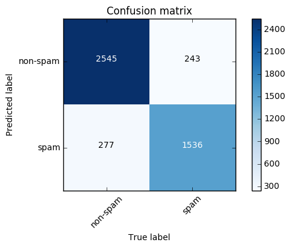

**Confusion Matrix**

| Actual row_0 | 0 | 1 |
| --- | --- | --- |
| 0 | 2545 | 277 |
| 1 | 243 | 1536 |

**Classification Report**

```
             precision    recall  f1-score   support

          0       0.90      0.91      0.91      2788
          1       0.86      0.85      0.86      1813

avg / total       0.89      0.89      0.89      4601
```

**F Measure**

```
0.855233853007
```

**Kappa Score**

```
0.762555852252
```

**Matthews correlation coefficient**

```
0.762647768919
```

```python
# Model Evaluation using the highest accuracy k-values
clf_knn = neighbors.KNeighborsClassifier(3, weights = 'distance')
#clf_knn = clf_knn.fit(features, target)
#scores = cross_val_score(clf_knn, features, target['Actual'], cv=10)
model_evaluation(clf_knn,features,target,class_names,cnf_normalize=False)
```

## Logistic Regression

#### For Logistic regression, we use l2 norm regularization to enable better feature selection. Again, using TFIDF leads to the best accuracy

```python
#Not using TFIDF data
features = data_normal.iloc[:,0:57]
target = data_normal.iloc[:,57:]
target.columns = ['Actual']

# We start with initializing our classifier
from sklearn import linear_model
clf_log = linear_model.LogisticRegression(C=1e3, penalty='l2', tol=0.01)

scores = cross_val_score(clf, features, target['Actual'], cv=10)

#Accuracy
# The mean score and the 95% confidence interval of the score estimate are hence given by:
display(HTML('<br><b>Accuracy:</b>'))
print("Accuracy: %0.2f (+/- %0.2f)" % (scores.mean(), scores.std() * 2))
```

**Accuracy:**

```
Accuracy: 0.90 (+/- 0.07)
```

```python
#Using TFIDF data
features = data_tfidf_normal.iloc[:,0:57]
target = data_tfidf_normal.iloc[:,57:]
target.columns = ['Actual']

# We start with initializing our classifier
clf_log = linear_model.LogisticRegression(C=1e3, penalty='l2', tol=0.01)

scores = cross_val_score(clf_log, features, target['Actual'], cv=10)

#Accuracy
# The mean score and the 95% confidence interval of the score estimate are hence given by:
display(HTML('<br><b>Accuracy:</b>'))
print("Accuracy: %0.2f (+/- %0.2f)" % (scores.mean(), scores.std() * 2))
```

**Accuracy:**

```
Accuracy: 0.92 (+/- 0.06)
```

**Accuracy:**

```
Accuracy: 0.92 (+/- 0.06)
Confusion matrix, without normalization
```

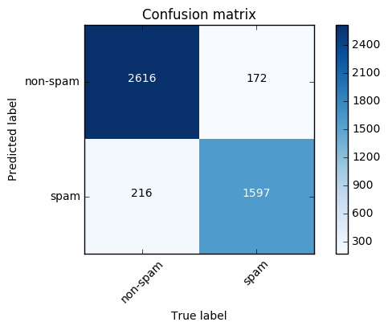

**Confusion Matrix**

| Actual row_0 | 0 | 1 |
| --- | --- | --- |
| 0 | 2616 | 216 |
| 1 | 172 | 1597 |

**Classification Report**

```
             precision    recall  f1-score   support

          0       0.92      0.94      0.93      2788
          1       0.90      0.88      0.89      1813

avg / total       0.92      0.92      0.92      4601
```

**F Measure**

```
0.891680625349
```

**Kappa Score**

```
0.822658534521
```

**Matthews correlation coefficient**

```
0.822824946223
```

```python
#clf_log = clf_l2_LR.fit(features, target)
#scores = cross_val_score(clf_log, features, target['Actual'], cv=10)
model_evaluation(clf_log,features,target,class_names,cnf_normalize=False)
```

## Naive Bayes

```python
#Not using TFIDF data
features = data_normal.iloc[:,0:57]
target = data_normal.iloc[:,57:]
target.columns = ['Actual']

from sklearn.naive_bayes import MultinomialNB, GaussianNB
clf_nb = MultinomialNB()
#clf_nb = GaussianNB()

scores = cross_val_score(clf_nb, features, target['Actual'], cv=10)

#Accuracy
# The mean score and the 95% confidence interval of the score estimate are hence given by:
display(HTML('<br><b>Accuracy:</b>'))
print("Accuracy: %0.2f (+/- %0.2f)" % (scores.mean(), scores.std() * 2))
```

**Accuracy:**

```
Accuracy: 0.88 (+/- 0.07)
```

```python
#Using TFIDF data
features = data_tfidf_normal.iloc[:,0:57]
target = data_tfidf_normal.iloc[:,57:]
target.columns = ['Actual']

clf_nb = MultinomialNB()
#clf_nb = GaussianNB()

scores = cross_val_score(clf_nb, features, target['Actual'], cv=10)

#Accuracy
# The mean score and the 95% confidence interval of the score estimate are hence given by:
display(HTML('<br><b>Accuracy:</b>'))
print("Accuracy: %0.2f (+/- %0.2f)" % (scores.mean(), scores.std() * 2))
```

**Accuracy:**

```
Accuracy: 0.85 (+/- 0.05)
```

**Accuracy:**

```
Accuracy: 0.85 (+/- 0.05)
Confusion matrix, without normalization
```

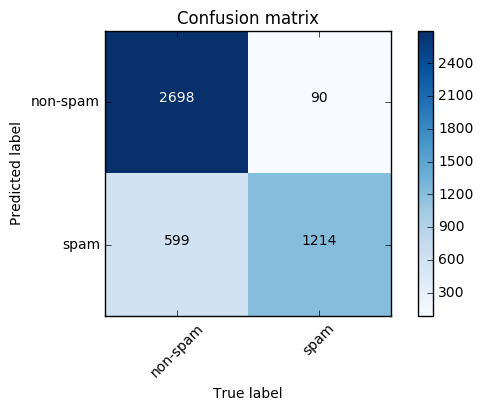

**Confusion Matrix**

| Actual row_0 | 0 | 1 |
| --- | --- | --- |
| 0 | 2698 | 599 |
| 1 | 90 | 1214 |

**Classification Report**

```
             precision    recall  f1-score   support

          0       0.82      0.97      0.89      2788
          1       0.93      0.67      0.78      1813

avg / total       0.86      0.85      0.84      4601
```

**F Measure**

```
0.778954122554
```

**Kappa Score**

```
0.670229406743
```

**Matthews correlation coefficient**

```
0.691049976905
```

```python
#scores = cross_val_score(clf_nb, features, target['Actual'], cv=10)
model_evaluation(clf_nb,features,target,class_names,cnf_normalize=False)
```

## Part 2: Misclassification Cost

#### We define a scorer function to eable us to judge a model based on misclassification cost

### Evaluation metrics

```python
from sklearn.metrics import make_scorer

def my_scorer_function(y_test, y_predicted):
    cm = confusion_matrix(y_test, y_predicted)
    return float(cm[0][1]*10 + cm[1][0]*1)/(cm[0][0] + cm[0][1] + cm[1][0] + cm[1][1])
```

## Decision Tree

```python
#Without using TFIDF data
features = data.iloc[:,0:57]
target = data.iloc[:,57:]
target.columns = ['Actual']

# Model Evaluation using cross validation
scores = cross_val_score(clf, features, target['Actual'], cv=10, scoring=make_scorer(my_scorer_function))

#The mean score and the 95% confidence interval of the score estimate are hence given by:
display(HTML('<br><b>Misclassification Cost:</b>'))
print("Cost: %0.2f (+/- %0.2f)" % (scores.mean(), scores.std() * 2))
```

**Misclassification Cost:**

```
Cost: 0.50 (+/- 0.64)
```

```python
#Using TFIDF data
features = data_tfidf.iloc[:,0:57]
target = data_tfidf.iloc[:,57:]
target.columns = ['Actual']

# Model Evaluation using cross validation
scores = cross_val_score(clf, features, target['Actual'], cv=10, scoring=make_scorer(my_scorer_function))

#The mean score and the 95% confidence interval of the score estimate are hence given by:
display(HTML('<br><b>Misclassification Cost:</b>'))
print("Cost: %0.2f (+/- %0.2f)" % (scores.mean(), scores.std() * 2))
```

**Misclassification Cost:**

```
Cost: 0.48 (+/- 0.45)
```

```python
#Without using TFIDF data
features = data_normal.iloc[:,0:57]
target = data_normal.iloc[:,57:]
target.columns = ['Actual']

for n_neighbors in range(3,22,3):
    # we create an instance of Neighbours Classifier and fit the data.
    clf = neighbors.KNeighborsClassifier(n_neighbors, weights = 'distance')

    scores = cross_val_score(clf, features, target['Actual'], cv=10, scoring=make_scorer(my_scorer_function))

    #The mean score and the 95% confidence interval of the score estimate are hence given by:
    display(HTML('<br><b>Misclassification Cost:</b>'))
    print("Cost: %0.2f (+/- %0.2f)" % (scores.mean(), scores.std() * 2))
```

**Misclassification Cost:**

```
Cost: 0.59 (+/- 0.51)
```

**Misclassification Cost:**

```
Cost: 0.52 (+/- 0.39)
```

**Misclassification Cost:**

```
Cost: 0.54 (+/- 0.50)
```

**Misclassification Cost:**

```
Cost: 0.53 (+/- 0.56)
```

**Misclassification Cost:**

```
Cost: 0.53 (+/- 0.52)
```

**Misclassification Cost:**

```
Cost: 0.52 (+/- 0.57)
```

**Misclassification Cost:**

```
Cost: 0.49 (+/- 0.53)
```

```python
#Without using TFIDF data
features = data_tfidf_normal.iloc[:,0:57]
target = data_tfidf_normal.iloc[:,57:]
target.columns = ['Actual']

for n_neighbors in range(3,22,3):
    # we create an instance of Neighbours Classifier and fit the data.
    clf = neighbors.KNeighborsClassifier(n_neighbors, weights = 'distance')

    scores = cross_val_score(clf, features, target['Actual'], cv=10, scoring=make_scorer(my_scorer_function))

    #The mean score and the 95% confidence interval of the score estimate are hence given by:
    display(HTML('<br><b>Misclassification Cost:</b>'))
    print("Cost: %0.2f (+/- %0.2f)" % (scores.mean(), scores.std() * 2))
```

**Misclassification Cost:**

```
Cost: 0.59 (+/- 0.56)
```

**Misclassification Cost:**

```
Cost: 0.54 (+/- 0.44)
```

**Misclassification Cost:**

```
Cost: 0.58 (+/- 0.50)
```

**Misclassification Cost:**

```
Cost: 0.54 (+/- 0.47)
```

**Misclassification Cost:**

```
Cost: 0.54 (+/- 0.51)
```

**Misclassification Cost:**

```
Cost: 0.52 (+/- 0.51)
```

**Misclassification Cost:**

```
Cost: 0.53 (+/- 0.54)
```

## Logistic Regression

```python
#Without using TFIDF data
features = data_normal.iloc[:,0:57]
target = data_normal.iloc[:,57:]
target.columns = ['Actual']

from sklearn import linear_model
clf_log = linear_model.LogisticRegression(C=1e3, penalty='l2', tol=0.01)

# Model Evaluation using cross validation
scores = cross_val_score(clf_log, features, target['Actual'], cv=10, scoring=make_scorer(my_scorer_function))

#The mean score and the 95% confidence interval of the score estimate are hence given by:
display(HTML('<br><b>Misclassification Cost:</b>'))
print("Cost: %0.2f (+/- %0.2f)" % (scores.mean(), scores.std() * 2))
```

**Misclassification Cost:**

```
Cost: 0.40 (+/- 0.46)
```

```python
#Using TFIDF data
features = data_tfidf_normal.iloc[:,0:57]
target = data_tfidf_normal.iloc[:,57:]
target.columns = ['Actual']

from sklearn import linear_model
clf_log = linear_model.LogisticRegression(C=1e3, penalty='l2', tol=0.01)

# Model Evaluation using cross validation
scores = cross_val_score(clf_log, features, target['Actual'], cv=10, scoring=make_scorer(my_scorer_function))

#The mean score and the 95% confidence interval of the score estimate are hence given by:
display(HTML('<br><b>Misclassification Cost:</b>'))
print("Cost: %0.2f (+/- %0.2f)" % (scores.mean(), scores.std() * 2))
```

**Misclassification Cost:**

```
Cost: 0.42 (+/- 0.46)
```

## Naive Bayes

```python
#Without using TFIDF data
features = data_normal.iloc[:,0:57]
target = data_normal.iloc[:,57:]
target.columns = ['Actual']

from sklearn.naive_bayes import MultinomialNB, GaussianNB
clf_nb = MultinomialNB()

# Model Evaluation using cross validation
scores = cross_val_score(clf_nb, features, target['Actual'], cv=10, scoring=make_scorer(my_scorer_function))

#The mean score and the 95% confidence interval of the score estimate are hence given by:
display(HTML('<br><b>Misclassification Cost:</b>'))
print("Cost: %0.2f (+/- %0.2f)" % (scores.mean(), scores.std() * 2))
```

**Misclassification Cost:**

```
Cost: 0.43 (+/- 0.53)
```

```python
#Using TFIDF data
features = data_tfidf_normal.iloc[:,0:57]
target = data_tfidf_normal.iloc[:,57:]
target.columns = ['Actual']

from sklearn.naive_bayes import MultinomialNB, GaussianNB
clf_nb = MultinomialNB()

# Model Evaluation using cross validation
scores = cross_val_score(clf_nb, features, target['Actual'], cv=10, scoring=make_scorer(my_scorer_function))

#The mean score and the 95% confidence interval of the score estimate are hence given by:
display(HTML('<br><b>Misclassification Cost:</b>'))
print("Cost: %0.2f (+/- %0.2f)" % (scores.mean(), scores.std() * 2))
```

**Misclassification Cost:**

```
Cost: 0.33 (+/- 0.21)
```

### Conclusion

#### Best Model in terms of Accuracy: Logistic Regression with TFIDF - Accuracy = 92%

#### Best Model in terms of Misclassification Cost: Naive Bayes with TFIDF - Cost = 0.33